# FIFA 2021 Player Analysis

[figure not shown]

```python
from IPython import display
display.Image("Fifa.png")
```

### By: Nathan Chung

### Outline

- Introduction
  - Set Up
  - Background Information
- Data Collection/Data Management
  - What is the data?
  - Getting Data
  - Data Cleaning
- Exploratory Data Analysis
  - Creating useful visualizations
  - Start Process of analyzing
- Machine Learning
- Conclusion

## Introduction

This Data Science Tutorial will guide you through the Data Science Pipeline. In this project we are analyzing soccer player's data from Fifa 2021. More specifically we will be finding relationships and trends within the datasets between the top 5 plyaers in the world to later on create and test a model.

### Background Information

Fifa is the International Federation of Association Football. This organization organizes and manages world football, holding the World Cup Final that happens every four years. Over the past two decades, EA Sports has developed FIFA soccer games that are released annually. In this series of soccer games, each one has curated real world teams and players, where each individual soccer player is given a ranking out of 100, depending on their player statistics that vary from shooting, passing, dribbling, etc.

### Set Up

In this project, we are using several useful libraries that exist in python. Down below are all of the packages that we will be using in this tutorial.

More information on python libraries:

- https://data-flair.training/blogs/python-libraries/

```python
import requests
import numpy as np
import pandas as pd
from ggplot import *
import seaborn as sns
from bs4 import BeautifulSoup
import urllib.request
%matplotlib inline
import matplotlib.pyplot as plt
from sklearn.linear_model import LinearRegression
import sklearn.linear_model as lm
from sklearn.linear_model import LogisticRegression
from sklearn.metrics import classification_report, confusion_matrix
import statsmodels.api as sm
import os
import plotly.graph_objects as go
from plotly.subplots import make_subplots
```

## Data Collection/Data Management

### What is the data?

The datasets that are used in this project are made up of soccer player's data from the Career Mode in each Fifa game from 2021.

The data is taken from kaggle which is an online public data base. The link to the repository for the data is down below. All of the files are labeled **players_XX.csv** where **XX** denotes which Fifa year the data was taken from.

- https://www.kaggle.com/stefanoleone992/fifa-21-complete-player-dataset

### Getting Data

In order to get the data, you will go to the link https://www.kaggle.com/stefanoleone992/fifa-21-complete-player-dataset and download the file 'players_21.csv'.

Notice that each file ends with a .csv. These are 'Comma Separated Values' files which are extremely common in data science. These files are used for exchanging data between different applications. In order to make these files usable for this project, we need to read them into a dataframe by utilizing Python Pandas' dataframe with **read_csv**.

Once we have the datasets loaded into dataframes, we use **.head()** to display the data in table format to get a first glimpse of what we are looking at.

```python
# Reading each file into dataframes for preparation and analysis.
data_21 = pd.read_csv('players_21.csv')

# Prinding out first 50 rows in dataframe that has Fifa 2021 dataset.
# Each dataset has the same columns and same information. So looking at one dataset will show what others will look like.
data_21.head()
```

|  | sofifa_id | player_url | short_name | long_name | age | dob | height_cm | weight_kg | nationality | club_name | ... | lwb | ldm | cdm | rdm | rwb | lb | lcb | cb | rcb | rb |
| --- | --- | --- | --- | --- | --- | --- | --- | --- | --- | --- | --- | --- | --- | --- | --- | --- | --- | --- | --- | --- | --- |
| 0 | 158023 | https://sofifa.com/player/158023/lionel-messi/... | L. Messi | Lionel Andrés Messi Cuccittini | 33 | 1987-06-24 | 170 | 72 | Argentina | FC Barcelona | ... | 66+3 | 65+3 | 65+3 | 65+3 | 66+3 | 62+3 | 52+3 | 52+3 | 52+3 | 62+3 |
| 1 | 20801 | https://sofifa.com/player/20801/c-ronaldo-dos-... | Cristiano Ronaldo | Cristiano Ronaldo dos Santos Aveiro | 35 | 1985-02-05 | 187 | 83 | Portugal | Juventus | ... | 65+3 | 61+3 | 61+3 | 61+3 | 65+3 | 61+3 | 54+3 | 54+3 | 54+3 | 61+3 |
| 2 | 200389 | https://sofifa.com/player/200389/jan-oblak/210002 | J. Oblak | Jan Oblak | 27 | 1993-01-07 | 188 | 87 | Slovenia | Atlético Madrid | ... | 32+3 | 36+3 | 36+3 | 36+3 | 32+3 | 32+3 | 33+3 | 33+3 | 33+3 | 32+3 |
| 3 | 188545 | https://sofifa.com/player/188545/robert-lewand... | R. Lewandowski | Robert Lewandowski | 31 | 1988-08-21 | 184 | 80 | Poland | FC Bayern München | ... | 64+3 | 65+3 | 65+3 | 65+3 | 64+3 | 61+3 | 60+3 | 60+3 | 60+3 | 61+3 |
| 4 | 190871 | https://sofifa.com/player/190871/neymar-da-sil... | Neymar Jr | Neymar da Silva Santos Júnior | 28 | 1992-02-05 | 175 | 68 | Brazil | Paris Saint-Germain | ... | 67+3 | 62+3 | 62+3 | 62+3 | 67+3 | 62+3 | 49+3 | 49+3 | 49+3 | 62+3 |

5 rows × 106 columns

```python
# Printing out the number of columns in the dataframe.
print("Number of Columns: " + str(len(data_21.columns)))
```

```
Number of Columns: 106
```

### Data Cleaning

As we can see, there are 106 columns in each dataset. A lot of the these columns are not very practical and will not be used in this project such as **rs, lw, lf, cf, etc** (columns that give a player a value fore each and every position).

In this tutorial, our focus is to try to develop a model that can deem itself to be accurate enough to find trends and relationships in the data. Having all of the extra data is not needed so in this step, we will **clean the data**.

```python
# Using iloc() function from Pandas Library to reformat datasets so that that only contain information we need.
data_21 = data_21.iloc[:, 0:75]

# Displaying head of the new dataset.
data_21.head()
```

|  | sofifa_id | player_url | short_name | long_name | age | dob | height_cm | weight_kg | nationality | club_name | ... | power_long_shots | mentality_aggression | mentality_interceptions | mentality_positioning | mentality_vision | mentality_penalties | mentality_composure | defending_marking | defending_standing_tackle | defending_sliding_tackle |
| --- | --- | --- | --- | --- | --- | --- | --- | --- | --- | --- | --- | --- | --- | --- | --- | --- | --- | --- | --- | --- | --- |
| 0 | 158023 | https://sofifa.com/player/158023/lionel-messi/... | L. Messi | Lionel Andrés Messi Cuccittini | 33 | 1987-06-24 | 170 | 72 | Argentina | FC Barcelona | ... | 94 | 44 | 40 | 93 | 95 | 75 | 96 | NaN | 35 | 24 |
| 1 | 20801 | https://sofifa.com/player/20801/c-ronaldo-dos-... | Cristiano Ronaldo | Cristiano Ronaldo dos Santos Aveiro | 35 | 1985-02-05 | 187 | 83 | Portugal | Juventus | ... | 93 | 63 | 29 | 95 | 82 | 84 | 95 | NaN | 32 | 24 |
| 2 | 200389 | https://sofifa.com/player/200389/jan-oblak/210002 | J. Oblak | Jan Oblak | 27 | 1993-01-07 | 188 | 87 | Slovenia | Atlético Madrid | ... | 12 | 34 | 19 | 11 | 65 | 11 | 68 | NaN | 12 | 18 |
| 3 | 188545 | https://sofifa.com/player/188545/robert-lewand... | R. Lewandowski | Robert Lewandowski | 31 | 1988-08-21 | 184 | 80 | Poland | FC Bayern München | ... | 85 | 81 | 49 | 94 | 79 | 88 | 88 | NaN | 42 | 19 |
| 4 | 190871 | https://sofifa.com/player/190871/neymar-da-sil... | Neymar Jr | Neymar da Silva Santos Júnior | 28 | 1992-02-05 | 175 | 68 | Brazil | Paris Saint-Germain | ... | 84 | 51 | 36 | 87 | 90 | 92 | 93 | NaN | 30 | 29 |

5 rows × 75 columns

```python
# List of column names we want to drop
lst = ['value_eur','player_url', 'wage_eur', 'body_type', 'skill_moves', 'weak_foot', 'nation_jersey_number', 'nation_position', 'international_reputation', 'work_rate','real_face','release_clause_eur','loaned_from', 'team_position','player_tags', 'team_jersey_number','contract_valid_until', 'loaned_from', 'joined', 'gk_diving', 'gk_handling', 'gk_kicking', 'gk_reflexes', 'gk_speed', 'gk_positioning', 'player_traits', 'defending_marking', 'defending_standing_tackle', 'defending_sliding_tackle']

# Dropping all the columns with names corresponding to strings in lst that was initialized above.
data_21.drop(lst, inplace = True, axis = 1)
data_21
```

|  | sofifa_id | short_name | long_name | age | dob | height_cm | weight_kg | nationality | club_name | league_name | ... | power_jumping | power_stamina | power_strength | power_long_shots | mentality_aggression | mentality_interceptions | mentality_positioning | mentality_vision | mentality_penalties | mentality_composure |
| --- | --- | --- | --- | --- | --- | --- | --- | --- | --- | --- | --- | --- | --- | --- | --- | --- | --- | --- | --- | --- | --- |
| 0 | 158023 | L. Messi | Lionel Andrés Messi Cuccittini | 33 | 1987-06-24 | 170 | 72 | Argentina | FC Barcelona | Spain Primera Division | ... | 68 | 72 | 69 | 94 | 44 | 40 | 93 | 95 | 75 | 96 |
| 1 | 20801 | Cristiano Ronaldo | Cristiano Ronaldo dos Santos Aveiro | 35 | 1985-02-05 | 187 | 83 | Portugal | Juventus | Italian Serie A | ... | 95 | 84 | 78 | 93 | 63 | 29 | 95 | 82 | 84 | 95 |
| 2 | 200389 | J. Oblak | Jan Oblak | 27 | 1993-01-07 | 188 | 87 | Slovenia | Atlético Madrid | Spain Primera Division | ... | 78 | 41 | 78 | 12 | 34 | 19 | 11 | 65 | 11 | 68 |
| 3 | 188545 | R. Lewandowski | Robert Lewandowski | 31 | 1988-08-21 | 184 | 80 | Poland | FC Bayern München | German 1. Bundesliga | ... | 84 | 76 | 86 | 85 | 81 | 49 | 94 | 79 | 88 | 88 |
| 4 | 190871 | Neymar Jr | Neymar da Silva Santos Júnior | 28 | 1992-02-05 | 175 | 68 | Brazil | Paris Saint-Germain | French Ligue 1 | ... | 62 | 81 | 50 | 84 | 51 | 36 | 87 | 90 | 92 | 93 |
| ... | ... | ... | ... | ... | ... | ... | ... | ... | ... | ... | ... | ... | ... | ... | ... | ... | ... | ... | ... | ... | ... |
| 18939 | 256679 | K. Angulo | Kevin Angulo | 24 | 1996-04-13 | 176 | 73 | Colombia | América de Cali | Colombian Liga Postobón | ... | 57 | 40 | 51 | 36 | 57 | 41 | 31 | 49 | 39 | 36 |
| 18940 | 257710 | Zhang Mengxuan | Mengxuan Zhang | 21 | 1999-04-26 | 177 | 70 | China PR | Chongqing Dangdai Lifan FC SWM Team | Chinese Super League | ... | 65 | 55 | 45 | 23 | 44 | 50 | 25 | 25 | 35 | 40 |
| 18941 | 250989 | Wang Zhenghao | 王政豪 | 20 | 2000-06-28 | 185 | 74 | China PR | Tianjin TEDA FC | Chinese Super League | ... | 69 | 58 | 55 | 22 | 46 | 45 | 25 | 25 | 35 | 40 |
| 18942 | 257697 | Chen Zitong | Zitong Chen | 23 | 1997-02-20 | 186 | 80 | China PR | Shijiazhuang Ever Bright F.C. | Chinese Super League | ... | 56 | 48 | 63 | 33 | 56 | 40 | 31 | 45 | 42 | 43 |
| 18943 | 257936 | Song Yue | Yue Song | 28 | 1991-11-20 | 185 | 79 | China PR | Tianjin TEDA FC | Chinese Super League | ... | 59 | 54 | 62 | 34 | 57 | 35 | 48 | 44 | 36 | 35 |

18944 rows × 47 columns

As you can see, we now have what seems to be a more friendly dataset that can be analyzed without the extra jargon information.

### More Data Cleaning

We can also knock our two birds with one stone. In the FIFA 2021 roster, each and every player for each and every position is recorded, including Goal Keepers. Goal Keepers have entirely different statistics that are recorded from their performance compared to field players like strikers and midfielders. As a matter of fact, for the statistics for field players such as **shooting, passing, and dribbling**, almost each and every goalkeeper has a missing **NaN** value which if we keep in the data will cause issues later on when applying regression.

In this project, we are mainly focusing on field players like midfielders or strikers, so we can eliminate all goal keepers that are listed in the data set.

```python
# Our method of finding the top 50 players from FIFA2021 is by using the 'overall' ranking of the player and sorting them.
df = data_21.sort_values(by='overall',ascending=False).head(200)

# Iterrating through each row and column in the dataframe, checking if the player position is a GK to identify goalkeepers and remove them.
for index, row in df.iterrows():
    # Conditional that checks each player if they are a Goal Keeper or not.
    if (row['player_positions'] == 'GK'):
        # The .drop() function is a very useful pandas datafrem functionality that is used for data cleaning.
        # Drop can be used to get rid of specific columns/rows which can deem itself very useful and efficient for eliminating useless data.
        df = df.drop(index, axis=0)

df.head()
```

|  | sofifa_id | short_name | long_name | age | dob | height_cm | weight_kg | nationality | club_name | league_name | ... | power_jumping | power_stamina | power_strength | power_long_shots | mentality_aggression | mentality_interceptions | mentality_positioning | mentality_vision | mentality_penalties | mentality_composure |
| --- | --- | --- | --- | --- | --- | --- | --- | --- | --- | --- | --- | --- | --- | --- | --- | --- | --- | --- | --- | --- | --- |
| 0 | 158023 | L. Messi | Lionel Andrés Messi Cuccittini | 33 | 1987-06-24 | 170 | 72 | Argentina | FC Barcelona | Spain Primera Division | ... | 68 | 72 | 69 | 94 | 44 | 40 | 93 | 95 | 75 | 96 |
| 1 | 20801 | Cristiano Ronaldo | Cristiano Ronaldo dos Santos Aveiro | 35 | 1985-02-05 | 187 | 83 | Portugal | Juventus | Italian Serie A | ... | 95 | 84 | 78 | 93 | 63 | 29 | 95 | 82 | 84 | 95 |
| 3 | 188545 | R. Lewandowski | Robert Lewandowski | 31 | 1988-08-21 | 184 | 80 | Poland | FC Bayern München | German 1. Bundesliga | ... | 84 | 76 | 86 | 85 | 81 | 49 | 94 | 79 | 88 | 88 |
| 4 | 190871 | Neymar Jr | Neymar da Silva Santos Júnior | 28 | 1992-02-05 | 175 | 68 | Brazil | Paris Saint-Germain | French Ligue 1 | ... | 62 | 81 | 50 | 84 | 51 | 36 | 87 | 90 | 92 | 93 |
| 5 | 192985 | K. De Bruyne | Kevin De Bruyne | 29 | 1991-06-28 | 181 | 70 | Belgium | Manchester City | English Premier League | ... | 63 | 89 | 74 | 91 | 76 | 66 | 88 | 94 | 84 | 91 |

5 rows × 47 columns

## Exploratory Data Analysis

Exploratory Data Analysis the processs where you do your initial analysis and breakdown of the data to look for any trends, patterns, anomalies, as well as summarizing the different characteristics of the data. EDA is done before any assumptions are made about the data set.

This process helps a data scientist find out how to best manipulate the data to get the answers of their desired interest.

Although this is only a brief overview on what Exploratory Data Analysis consists of, a more detailed source of information can be found below

- https://www.ibm.com/cloud/learn/exploratory-data-analysis

### Understanding the Data

As we can see, there are several different columns in our newly cleaned and processed dataset. Whats important is that we know what each of these components are and that we understand what their purpose is. This is crucial before starting any EDA because you should have a good understanding of what your data consists of.

```python
df.head()
```

|  | sofifa_id | short_name | long_name | age | dob | height_cm | weight_kg | nationality | club_name | league_name | ... | power_jumping | power_stamina | power_strength | power_long_shots | mentality_aggression | mentality_interceptions | mentality_positioning | mentality_vision | mentality_penalties | mentality_composure |
| --- | --- | --- | --- | --- | --- | --- | --- | --- | --- | --- | --- | --- | --- | --- | --- | --- | --- | --- | --- | --- | --- |
| 0 | 158023 | L. Messi | Lionel Andrés Messi Cuccittini | 33 | 1987-06-24 | 170 | 72 | Argentina | FC Barcelona | Spain Primera Division | ... | 68 | 72 | 69 | 94 | 44 | 40 | 93 | 95 | 75 | 96 |
| 1 | 20801 | Cristiano Ronaldo | Cristiano Ronaldo dos Santos Aveiro | 35 | 1985-02-05 | 187 | 83 | Portugal | Juventus | Italian Serie A | ... | 95 | 84 | 78 | 93 | 63 | 29 | 95 | 82 | 84 | 95 |
| 3 | 188545 | R. Lewandowski | Robert Lewandowski | 31 | 1988-08-21 | 184 | 80 | Poland | FC Bayern München | German 1. Bundesliga | ... | 84 | 76 | 86 | 85 | 81 | 49 | 94 | 79 | 88 | 88 |
| 4 | 190871 | Neymar Jr | Neymar da Silva Santos Júnior | 28 | 1992-02-05 | 175 | 68 | Brazil | Paris Saint-Germain | French Ligue 1 | ... | 62 | 81 | 50 | 84 | 51 | 36 | 87 | 90 | 92 | 93 |
| 5 | 192985 | K. De Bruyne | Kevin De Bruyne | 29 | 1991-06-28 | 181 | 70 | Belgium | Manchester City | English Premier League | ... | 63 | 89 | 74 | 91 | 76 | 66 | 88 | 94 | 84 | 91 |

5 rows × 47 columns

Our main focus is to understand the data values we will most focus on:

**Attributes we will focus on are:**

- **sofifa_id:** Unique id number for the player on Fifa
- **short_name:** Short Name of the player
- **long_name:** Long name of the player
- **age:** Age of the player
- **dob:** The player's date of birth
- **height_cm:** height of the player in cm
- **weight_kg:** weight of the player in kg
- **nationality:** Player's nationality
- **club_name:** The name of the club/team the player plays for
- **league_name:** The soccer league the player belongs to
- **league_rank:** The ranking of the league globally
- **overall:** Overall score/ranking for the player in the game (1-100)
- **potential:** Potential score of the player (1-100)
- **player_positions:** Soccer position the player is
- **pace:** Player's pace score (out of 100)
- **shooting:** Player's shooting score (out of 100)
- **passing:** Player's passing score (out of 100)
- **dribbling:** Player's dribbling score (out of 100)
- **defending:** Player's defending score (out of 100)
- **physic:** Player's phsyic score (out of 100)
- **attacking_crossing**: Player crossing Score (1-100)
- **attacking_finishing**: Player Finishing Score (1-100)
- **attacking_heading_accuracy**: Player Header Accuracy Score (1-100)
- **attacking_short_passing**: Player Short Passing Score (1-100)
- **mentality_aggression**: Player Aggression Score (1-100)
- **mentality_interceptions**: Reading Interceptions Score (1-100)
- **mentality_positioning**: Ability to make good positioning Score (1-100)
- **mentality_vision**: Field vision score (1-100)
- **mentality_penalties**: Penalty mentality score (1-100)
- **mentality_composure**: Composure during a game score (1-100)

Now since we have the data, we can first start off by showing the order of players from best to worst using different attributes of the data set. This can help identify players that consistently have presence in towards the top of the rankings for each attribute.

```python
# Sorting the values based off of player overall rank from highest to lowest to see order of best to worst player.
df.sort_values(by='overall',ascending=False)[['short_name','age','overall']]
```

|  | short_name | age | overall |
| --- | --- | --- | --- |
| 0 | L. Messi | 33 | 93 |
| 1 | Cristiano Ronaldo | 35 | 92 |
| 3 | R. Lewandowski | 31 | 91 |
| 4 | Neymar Jr | 28 | 91 |
| 5 | K. De Bruyne | 29 | 91 |
| ... | ... | ... | ... |
| 207 | D. Zapata | 29 | 83 |
| 206 | F. Kostić | 27 | 83 |
| 205 | Gerard Moreno | 28 | 83 |
| 203 | Jorginho | 28 | 83 |
| 173 | C. Vela | 31 | 83 |

174 rows × 3 columns

Looking at all of the rankings can only do so much. Our main goal is to find any relationships within the data. Constantly comparing each and every variable to each other can deem itself a challenging and time consuming task.

A more efficient approach is to use a **correlation matrix**. A correlation matrix shows any correlation between two variables, and is commonly used to summarize data to initiate the next step for analysis. Luckily in python, there is a library called seaborn that makes it easy to generate a correlation matrix.

**Seaborn** is a data visualization library in python that provides borth attractive and informative statistical graphs. More information can be found in the link below

- https://seaborn.pydata.org/

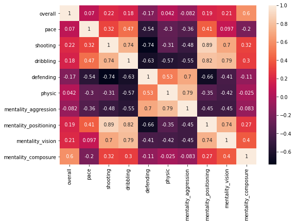

```python
df2 = df.sort_values(by='overall',ascending=False)[['overall', 'pace', 'shooting', 'dribbling', 'defending', 'physic', 'mentality_aggression', \
                                                    'mentality_positioning','mentality_vision', 'mentality_composure']]
plt.figure(figsize=(9,6))
corrMatrix = df2.corr()
sns.heatmap(corrMatrix, annot=True)
plt.show()
```

In order to interpret a correlation map, you look at the scoring for each component and see which others have similar equated scores. In this case, on our correlation matrix we can see that shooting scores for players are related to the dribbling scores, as well as there being a relationship between mentality_vision scores and mentality_positioning scores.

It make's sense now looking at the relationships that a player's mentality_vision will heavily influence their passing and shooting skill's as well as positioning.

From this, we can use this information to further explore those relationships through visualizations and graphs.

### Creating Useful Visualizations

Data visualization creates a visual summary which makes it much more easier to find relationships and trends in data rather than trying to process several columns and rows of data.

Gaining more insight is acheived with visual depictions of data becuase the data we are working with becomes more valuable when it is processed into a visualization.

One of the main goals of this entire project is to find out what make's the worlds best soccer player the best. In this case, Leonel Messi is the highest level ranked player in FIFA 2021, but what makes him so special?

To start, creating visuals to see how Messi differs from other players in different player stats can help. Since we are dealing with several different players of different caliber, a scatter plot would be the most ideal and adding a trend line will show whether a player is exceeding the average performance in that specific skill set or if they are below average.

We will visualize the relationship between a player's shooting ranking and their mentality_vision ranking. A crucial skill to have on the soccer field is having the visual prowess to read where everyone is on the field, and with that knowledge being able to attack the opposing team's defense in the best logical way.

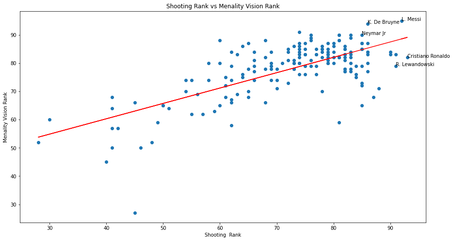

```python
# Seting size of graph we are about to produce
fig, ax = plt.subplots(figsize=(15,8))
# Setting x and y variables to hold focus data
x = df['shooting']
y = df['mentality_vision']
# Creating a scatter plot using the x and y variables we created
ax.plot(x, y, 'o')
# Here, we are using np.poly fit to add a regression line that shows how the Overall Rank changes as the Shooting Score Changes.
# m represents the slope and b represents the intercept of the linear regression line.
m, b = np.polyfit(x,y, 1)
# Plotting/adding the regression line.
plt.plot(x, m*x+b, color = 'red')

# This loop goes through each player in the list, and looks for the top 5 ranked players.
# This will help narrow down on the variance of skill and comparing players that are around the same skillset as Messi will be a more effective analysis.
for idx, row in df.iterrows():
    name = row['short_name']
    x = row['shooting']
    y = row['mentality_vision']
    if(name == 'L. Messi' or name == 'Cristiano Ronaldo' or \
       name == 'R. Lewandowski' or name == 'Neymar Jr' or name == 'K. De Bruyne'):
        ax.annotate(name, (x, y))

# Setting the proper x-axis/y-axis labels and the title.
plt.xlabel('Shooting  Rank')
plt.ylabel('Menality Vision Rank')
plt.title('Shooting Rank vs Menality Vision Rank')
plt.show()
```

As we can see, Messi has the highest performance in mentality vision.

We will visualize the relationship between a player's passing ranking and their mentality_vision ranking.

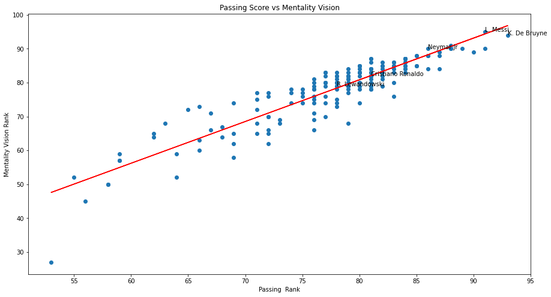

```python
# Seting size of graph we are about to produce
fig, ax = plt.subplots(figsize=(15,8))
# Setting x and y variables to hold focus data
x = df['passing']
y = df['mentality_vision']
# Creating a scatter plot using the x and y variables we created
ax.plot(x, y, 'o')
# Here, we are using np.poly fit to add a regression line that shows how the Passing Score changes as the mentality_vision Score Changes.
# m represents the slope and b represents the intercept of the linear regression line.
m, b = np.polyfit(x,y, 1)
# Plotting/adding the regression line.
plt.plot(x, m*x+b, color = 'red')

# This loop goes through each player in the list, and looks for the top 5 ranked players.
# This will help narrow down on the variance of skill and comparing players that are around the same skillset as Messi will be a more effective analysis.
for idx, row in df.iterrows():
    name = row['short_name']
    x = row['passing']
    y = row['mentality_vision']
    if(name == 'L. Messi' or name == 'Cristiano Ronaldo' or \
       name == 'R. Lewandowski' or name == 'Neymar Jr' or name == 'K. De Bruyne'):
        ax.annotate(name, (x, y))

# Setting the proper x-axis/y-axis labels and the title.
plt.xlabel('Passing  Rank')
plt.ylabel('Mentality Vision Rank')
plt.title('Passing Score vs Mentality Vision')
plt.show()
```

Here, we are starting to see bigger differences amongst the top 5 players that were labeled. The ongoing debate on whether Ronaldo or Messi is better has brought up constant debate. In this visualization we can see how Messi outshines Ronaldo in passing which makes us believe that the difference in this skill plays a big role in the overall ranking.

In this visualiztion, we are observing the relationship between a player's skill in passing and shooting.

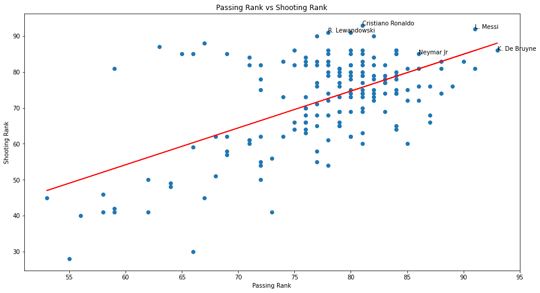

```python
# Seting size of graph we are about to produce
fig, ax = plt.subplots(figsize=(15,8))
# Setting x and y variables to hold focus data
x = df['passing']
y = df['shooting']
# Creating a scatter plot using the x and y variables we created
ax.plot(x, y, 'o')
# Here, we are using np.poly fit to add a regression line that shows how the Shooting Score changes as the Passing Score Changes.
# m represents the slope and b represents the intercept of the linear regression line.
m, b = np.polyfit(x,y, 1)
# Plotting/adding the regression line.
plt.plot(x, m*x+b, color = 'red')

# This loop goes through each player in the list, and looks for the top 5 ranked players.
# This will help narrow down on the variance of skill and comparing players that are around the same skillset as Messi will be a more effective analysis.
for idx, row in df.iterrows():
    name = row['short_name']
    x = row['passing']
    y = row['shooting']
    if(name == 'L. Messi' or name == 'Cristiano Ronaldo' or \
       name == 'R. Lewandowski' or name == 'Neymar Jr' or name == 'K. De Bruyne'):
        ax.annotate(name, (x, y))

# Setting the proper x-axis/y-axis labels and the title.
plt.xlabel('Passing Rank')
plt.ylabel('Shooting Rank')
plt.title('Passing Rank vs Shooting Rank')
plt.show()
```

Here we are taking a look at the relationship between a player's skill in dribbling and mentality_vison.

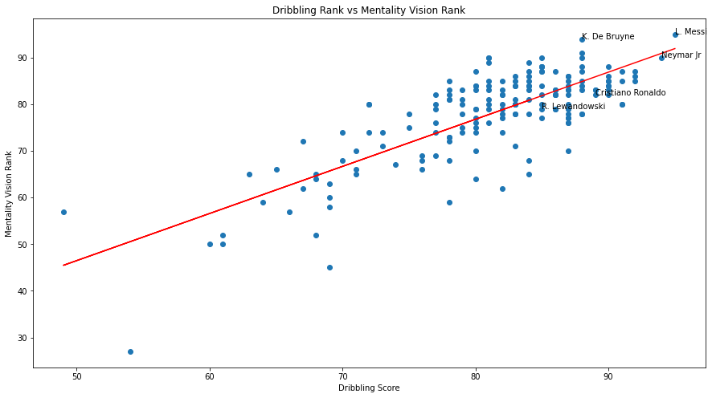

```python
# Seting size of graph we are about to produce
fig, ax = plt.subplots(figsize=(15,8))
# Setting x and y variables to hold focus data
x = df['dribbling']
y = df['mentality_vision']
# Creating a scatter plot using the x and y variables we created
ax.plot(x, y, 'o')
# Here, we are using np.poly fit to add a regression line that shows how the Dribbling Rank changes as the mentality_vision Score Changes.
# m represents the slope and b represents the intercept of the linear regression line.
m, b = np.polyfit(x,y, 1)
# Plotting/adding the regression line.
plt.plot(x, m*x+b, color = 'red')

for idx, row in df.iterrows():
    name = row['short_name']
    x = row['dribbling']
    y = row['mentality_vision']
    if(name == 'L. Messi' or name == 'Cristiano Ronaldo' or \
       name == 'R. Lewandowski' or name == 'Neymar Jr' or name == 'K. De Bruyne'):
        ax.annotate(name, (x, y))

# Setting the proper x-axis/y-axis labels and the title.
plt.xlabel('Dribbling Score')
plt.ylabel('Mentality Vision Rank')
plt.title('Dribbling Rank vs Mentality Vision Rank')
plt.show()
```

Here, we see that Lewandowski, Ronaldo, and Neymar are all below the trend line for the average dribbling skill. This shows these player's weaknesses.

### Another form of visualization

Scatter plots and trend lines are great and all, but sometimes, more than one type of visualization can be effective when trying to find the answer to youre question. In the next set of graphs, we are creating joint line graphs where we will take two players, and graph their set of skill rankings in a line plot. The two players will have different colored lines so that we can compare them in hand.

Here, we will compare the statistics of **Messi and Ronaldo**, two of the most well knowned and coveted soccer players in the world. Finding any major differences in their skillset will help us out in finding what minute differences these top tier players have in their game that make one better than the other.

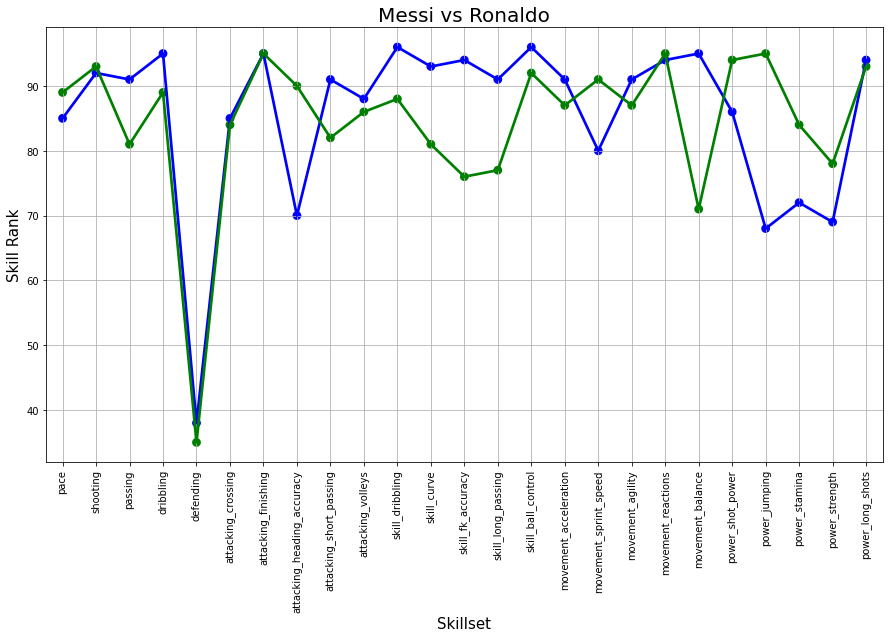

```python
# This is a list that has all of the attributes and skills that we want to plot for each player.
skills = ['pace', 'shooting', 'passing', 'dribbling', 'defending', 'attacking_crossing',
         'attacking_finishing', 'attacking_heading_accuracy', 'attacking_short_passing',
         'attacking_volleys', 'skill_dribbling', 'skill_curve', 'skill_fk_accuracy',
         'skill_long_passing', 'skill_ball_control', 'movement_acceleration', 'movement_sprint_speed',
         'movement_agility', 'movement_reactions', 'movement_balance', 'power_shot_power',
         'power_jumping', 'power_stamina', 'power_strength', 'power_long_shots']

# Here, we are creating the two dataframes for the players Messi and Ronaldo to be plotted together.
messi = df.loc[df.short_name == 'L. Messi']
messi = pd.DataFrame(messi, columns=skills)
ronaldo = df.loc[df.short_name == 'Cristiano Ronaldo']
ronaldo = pd.DataFrame(ronaldo, columns=skills)

# Setting the figure size.
plt.figure(figsize=(15,8))
# Messi's line will be Blue, and Ronaldo's line will be green.
sns.pointplot(data=messi,color='blue',alpha=0.6)
sns.pointplot(data=ronaldo, color='green', alpha=0.6)
plt.xticks(rotation=90)
# labeling proper axis
plt.xlabel('Skillset', fontsize=15)
plt.ylabel('Skill Rank', fontsize=15)
plt.title('Messi vs Ronaldo', fontsize = 20)
plt.grid()
```

By looking at each player's line (Messi-Blue, Ronaldo-Green), we see that both players are pretty similar with most skillsets. But one thing to note, is that towards the middle of each line plot where the data shows the players **attacking_short_passing, attacking_volleys, skill_dribbling, skill_curve, skill_fk_accurace, skill_long_passing, and skill_ball control**, Leonel Messi has notably higher rankings in those skillsets compared to Ronaldo.

This observation may be what we are looking for. It may be that because Messi is more skilled in **attacking_short_passing, attacking_volleys, skill_dribbling, skill_curve, skill_fk_accurace, skill_long_passing, and skill_ball control** than Ronaldo, that is what sets him apart.

Here, we will compare **Messi with Neymar**

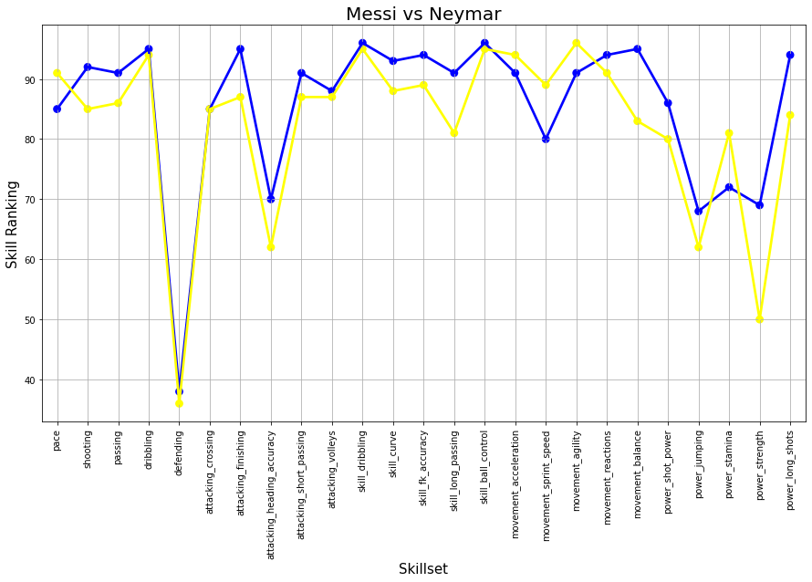

```python
# Here, we are creating the dataframes for the players Neymar.
neymar = df.loc[df.short_name == 'Neymar Jr']
neymar = pd.DataFrame(neymar, columns=skills)

# Setting the figure size.
plt.figure(figsize=(15,8))
sns.pointplot(data=messi,color='blue',alpha=0.5)
sns.pointplot(data=neymar, color='yellow', alpha=0.5)
plt.xticks(rotation=90)

# labeling proper axis
plt.xlabel('Skillset', fontsize=15)
plt.ylabel('Skill Ranking', fontsize=15)
plt.title('Messi vs Neymar', fontsize = 20)
plt.grid()
```

But with the skillsets **attacking_short_passing, attacking_volleys, skill_dribbling, skill_curve, skill_fk_accurace, skill_long_passing, and skill_ball control,** Leonel Messi has generally higher rankings in those skillsets compared to Neymar.

Now to take a step back, here, we find a similar/identical observation where Messi has generally higher rankings in those skillsets than Neymar. This only reinforces our initial findings.

Finally, for one more comparison, we will compare **Messi and Lewandowski**.

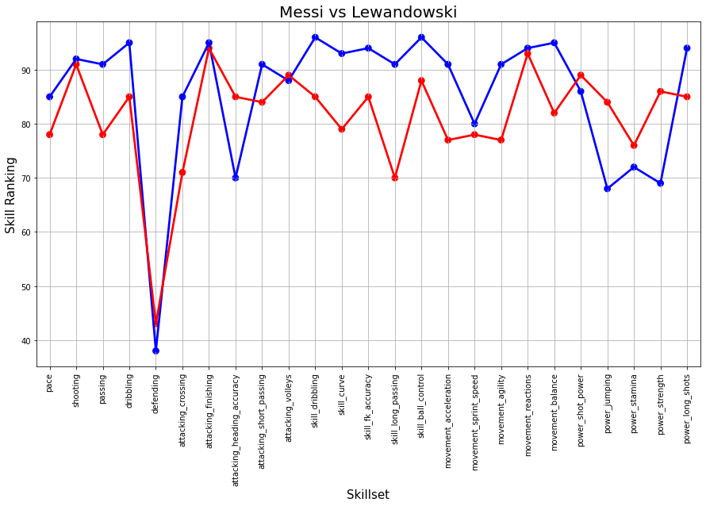

```python
lewand = df.loc[df.short_name == 'R. Lewandowski']
lewand = pd.DataFrame(lewand, columns=skills)

plt.figure(figsize=(15,8))
sns.pointplot(data=messi,color='blue',alpha=0.6)
sns.pointplot(data=lewand, color='red', alpha=0.6)
plt.xticks(rotation=90)
plt.xlabel('Skillset', fontsize=15)
plt.ylabel('Skill Ranking', fontsize=15)
plt.title('Messi vs Lewandowski', fontsize = 20)
plt.grid()
```

But with the skillsets **attacking_short_passing, attacking_volleys, skill_dribbling, skill_curve, skill_fk_accurace, skill_long_passing, and skill_ball control,** Leonel Messi has generally higher rankings in those skillsets compared to Lewandowski.

Now what have these findings told us? To recollect our thoughts and purpose, the reason why we decided to compare Messi (the top ranked player) with other elite players such as Ronaldo and Neymar was because comparing a highly skilled player with another player with a similar skillset is much more meaning full, whereas comparing Messi who is ranked 90+ with a player who is ranked 60 in FIFA will not help note any differences that help our case, because there will always be huge differences in the statistics. So that was our reason why we pulled the top 5 ranked players and compared them with each other.

## Machine Learning/Linear Regression

In data science, Machine Learning is a method of data analysis by using algorithms to find patterns in data. ML applies artificial intelligence where a system/model has the ability to learn and improve calculations/predictions based off of observation and experience, without having the need to do a lot of programing.

When given the task to predict some trend for a given data, it's very hard to come up with a fucntion or write code that can be accurate all the time because different variables in data are always changing. This is where machine learning comes into play. ML practices the use of algorithms to take in data into a system, learn from it, and then forecase and predict trends.

More information can be found in the link below:

- https://www.simplilearn.com/data-science-vs-data-analytics-vs-machine-learning-article

### Linear Regression

Linear Regression is a type of predictive analysis with two goals

- To find certain variables that can be used to predict values for a target outcome.
- To find which variables play a big role and are significant predictors of the outcome variables.

It is one of the most commonly used forms of regression/machine learning.

Linear regression is a part of machine learning where an algorithm is used to calculate a predicted outcome when inputed parameters/variables what we find have a large influence in the outcomes we are trying to predict.

More information can be found below:

- https://realpython.com/linear-regression-in-python/

```python
# Grabbing the independent variables which isn this case are {age, pace, shooting, passing, dribbling, defending, physic, etc}
x = df.iloc[:,[3,15,16,17, 18, 19, 20, 21, 22, 23, 24, 25, 26, 27, 28, 29, 30, 43, 44]]
x.head()
```

|  | age | pace | shooting | passing | dribbling | defending | physic | attacking_crossing | attacking_finishing | attacking_heading_accuracy | attacking_short_passing | attacking_volleys | skill_dribbling | skill_curve | skill_fk_accuracy | skill_long_passing | skill_ball_control | mentality_positioning | mentality_vision |
| --- | --- | --- | --- | --- | --- | --- | --- | --- | --- | --- | --- | --- | --- | --- | --- | --- | --- | --- | --- |
| 0 | 33 | 85.0 | 92.0 | 91.0 | 95.0 | 38.0 | 65.0 | 85 | 95 | 70 | 91 | 88 | 96 | 93 | 94 | 91 | 96 | 93 | 95 |
| 1 | 35 | 89.0 | 93.0 | 81.0 | 89.0 | 35.0 | 77.0 | 84 | 95 | 90 | 82 | 86 | 88 | 81 | 76 | 77 | 92 | 95 | 82 |
| 3 | 31 | 78.0 | 91.0 | 78.0 | 85.0 | 43.0 | 82.0 | 71 | 94 | 85 | 84 | 89 | 85 | 79 | 85 | 70 | 88 | 94 | 79 |
| 4 | 28 | 91.0 | 85.0 | 86.0 | 94.0 | 36.0 | 59.0 | 85 | 87 | 62 | 87 | 87 | 95 | 88 | 89 | 81 | 95 | 87 | 90 |
| 5 | 29 | 76.0 | 86.0 | 93.0 | 88.0 | 64.0 | 78.0 | 94 | 82 | 55 | 94 | 82 | 88 | 85 | 83 | 93 | 92 | 88 | 94 |

```python
# Grabbing the dependent variable which is Overall Ranking of a player
y=df.iloc[:,11]
y.head()
```

```
0    93
1    92
3    91
4    91
5    91
Name: overall, dtype: int64
```

Applying Linear Regression to our sets that we have made.

**To perform linear regression in python, we first have to prepare what is called train and test sets.**

- **Train Datasets**: are used to fit the machine learning model
  - Give the linear regression model data to learn from observation and experience.
  - This will help build the model
- **Test Datasets**: are used to evaluate the fit linear regression model.
  - These are used after the model is build using the train dataset.

```python
# train_test_split us a function from the SKlearn python library what splits up arrays into two subsets, one for training a linear regression model and one for testing the regression model.
x_train,x_test,y_train,y_test=train_test_split(x,y,test_size=0.2)
linreg=LinearRegression()
linreg.fit(x_train,y_train)
linreg.predict(x_test)
OLS=sm.OLS(endog=y,exog=x).fit()
OLS.summary()
```

OLS Regression Results

| Dep. Variable: | overall | R-squared (uncentered): | 0.999 |
| --- | --- | --- | --- |
| Model: | OLS | Adj. R-squared (uncentered): | 0.999 |
| Method: | Least Squares | F-statistic: | 1.379e+04 |
| Date: | Mon, 17 May 2021 | Prob (F-statistic): | 1.05e-239 |
| Time: | 12:20:35 | Log-Likelihood: | -373.25 |
| No. Observations: | 174 | AIC: | 784.5 |
| Df Residuals: | 155 | BIC: | 844.5 |
| Df Model: | 19 |  |  |
| Covariance Type: | nonrobust |  |  |

|  | coef | std err | t | P>\|t\| | [0.025 | 0.975] |
| --- | --- | --- | --- | --- | --- | --- |
| age | 0.2661 | 0.051 | 5.229 | 0.000 | 0.166 | 0.367 |
| pace | 0.1546 | 0.025 | 6.188 | 0.000 | 0.105 | 0.204 |
| shooting | 0.1040 | 0.077 | 1.343 | 0.181 | -0.049 | 0.257 |
| passing | 0.5677 | 0.652 | 0.871 | 0.385 | -0.721 | 1.856 |
| dribbling | 0.4292 | 0.196 | 2.189 | 0.030 | 0.042 | 0.816 |
| defending | -0.0155 | 0.020 | -0.766 | 0.445 | -0.055 | 0.024 |
| physic | 0.1299 | 0.034 | 3.819 | 0.000 | 0.063 | 0.197 |
| attacking_crossing | -0.1127 | 0.134 | -0.844 | 0.400 | -0.376 | 0.151 |
| attacking_finishing | 0.0105 | 0.055 | 0.190 | 0.850 | -0.099 | 0.120 |
| attacking_heading_accuracy | 0.0700 | 0.020 | 3.461 | 0.001 | 0.030 | 0.110 |
| attacking_short_passing | 0.1823 | 0.244 | 0.747 | 0.456 | -0.300 | 0.664 |
| attacking_volleys | -0.0285 | 0.028 | -1.017 | 0.311 | -0.084 | 0.027 |
| skill_dribbling | -0.3443 | 0.123 | -2.809 | 0.006 | -0.586 | -0.102 |
| skill_curve | -0.0571 | 0.049 | -1.159 | 0.248 | -0.154 | 0.040 |
| skill_fk_accuracy | -0.0552 | 0.037 | -1.495 | 0.137 | -0.128 | 0.018 |
| skill_long_passing | -0.1023 | 0.105 | -0.976 | 0.331 | -0.309 | 0.105 |
| skill_ball_control | 0.3058 | 0.107 | 2.869 | 0.005 | 0.095 | 0.516 |
| mentality_positioning | -0.1577 | 0.037 | -4.237 | 0.000 | -0.231 | -0.084 |
| mentality_vision | -0.1259 | 0.136 | -0.923 | 0.357 | -0.395 | 0.143 |

| Omnibus: | 8.103 | Durbin-Watson: | 1.517 |
| --- | --- | --- | --- |
| Prob(Omnibus): | 0.017 | Jarque-Bera (JB): | 13.540 |
| Skew: | 0.175 | Prob(JB): | 0.00115 |
| Kurtosis: | 4.321 | Cond. No. | 1.39e+03 |

Notes:  
[1] R² is computed without centering (uncentered) since the model does not contain a constant.  
[2] Standard Errors assume that the covariance matrix of the errors is correctly specified.  
[3] The condition number is large, 1.39e+03. This might indicate that there are  
strong multicollinearity or other numerical problems.

### How to Interpret the results from running linear regression?

- **R-squared** Identifies the percentage variation in the dependent variables that is explained by the independent variables.
- **Adj. R-squared** Is a modified R-squared value that is accounted for the number of variables in the regression.
- **P-Values** Represent the value from testing the hypothesis. In this case, a P-value is given for each independent variable we gave to the model where they are tested with the null hypothesis which is if there is **NO-Correlation** amongst the independent and dependent variables.
  - If the P-value is less than the significance level (p<0.05), that means that the model fits the data well and that there is moderate evidence against the null hypothesis.

### Reading the results from linear regression

As we can see, the independent variables **age, pace, dribbling, physic,attacking_heading_accuracy, skill_dribbling, skill_ball_control, and mentality_positioning** all have P-values less than 0.05 which means that those variables are significant and they can not be removed.

# Conclusion

In this tutorial, we went through the Data Science Pipeline where we learn to about **collecting data**, reading from csv files and transfering data from a website/online database into your own personal workspace, cleaning the data (unstructured to structured data), and starting the process of **Exploratory Data Analysis**.

Our main focus was to analyze soccer player's statistics from FIFA 2021, and find out which parts of a players game allows them to truly outshine others in their respective skill set with exception to the obvious differences that were surface level such as (skill rating 60 and skill rating 90, using overall rank), or very broad statistics like height or weight. Our goal was to dig deep into analysis and find out what specific components and variables came into play. In our EDA, we found trends and relationships by first utilizing a correlation matrix, and then with those findings from the correlation matrix, beginning the process of visualizing the data into graphs and charts. Our main methods of visualizations were through scatter plots with regression/trend lines as will is line plots to compare two players. We honed into and focused on the higher rated players in the data because it only made sense to compare a player of class A(similar skill) to another player of class A(similar skill).